# Correlation and regression

## Importing the required packages

```python
import matplotlib.pyplot as plt
import pandas as pd
import pylab as pl
import numpy as np
import seaborn as sns
```

## Load the data

```python
population=pd.read_csv("Global_Population.csv")
gdp=pd.read_csv("Global_GDP.csv")
```

```python
population.head(10)
```

|  | Country Name | Country Code | Series Name | Series Code | 1960 | 1961 | 1962 | 1963 | 1964 | 1965 | ... | 2012 | 2013 | 2014 | 2015 | 2016 | 2017 | 2018 | 2019 | 2020 | 2021 |
| --- | --- | --- | --- | --- | --- | --- | --- | --- | --- | --- | --- | --- | --- | --- | --- | --- | --- | --- | --- | --- | --- |
| 0 | Aruba | ABW | Population, total | SP.POP.TOTL | 54211 | 55438 | 56225 | 56695 | 57032 | 57360 | ... | 102560 | 103159 | 103774 | 104341 | 104872 | 105366 | 105845 | 106314 | NaN | NaN |
| 1 | Afghanistan | AFG | Population, total | SP.POP.TOTL | 8996967 | 9169406 | 9351442 | 9543200 | 9744772 | 9956318 | ... | 31161378 | 32269592 | 33370804 | 34413603 | 35383028 | 36296111 | 37171922 | 38041757 | 38928341 | 39835000 |
| 2 | Africa Eastern and Southern | AFE | Population, total | SP.POP.TOTL | 130836765 | 134159786 | 137614644 | 141202036 | 144920186 | 148769974 | ... | 547482863 | 562601578 | 578075373 | 593871847 | 609978946 | 626392880 | 643090131 | 660046272 | 677243299 | 694664000 |
| 3 | Africa Western and Central | AFW | Population, total | SP.POP.TOTL | 96396419 | 98407221 | 100506960 | 102691339 | 104953470 | 107289875 | ... | 370243017 | 380437896 | 390882979 | 401586651 | 412551299 | 423769930 | 435229381 | 446911598 | 458803476 | 470898000 |
| 4 | Albania | ALB | Population, total | SP.POP.TOTL | 1608800 | 1659800 | 1711319 | 1762621 | 1814135 | 1864791 | ... | 2900401 | 2895092 | 2889104 | 2880703 | 2876101 | 2873457 | 2866376 | 2854191 | 2837743 | 2832000 |
| 5 | Algeria | DZA | Population, total | SP.POP.TOTL | 11057864 | 11336336 | 11619828 | 11912800 | 12221675 | 12550880 | ... | 37383899 | 38140135 | 38923688 | 39728020 | 40551398 | 41389174 | 42228415 | 43053054 | 43851043 | 44617000 |
| 6 | American Samoa | ASM | Population, total | SP.POP.TOTL | 20127 | 20605 | 21246 | 22029 | 22850 | 23675 | ... | 55669 | 55717 | 55791 | 55806 | 55739 | 55617 | 55461 | 55312 | 55197 | 55000 |
| 7 | Andorra | AND | Population, total | SP.POP.TOTL | 13410 | 14378 | 15379 | 16407 | 17466 | 18542 | ... | 82427 | 80770 | 79213 | 77993 | 77295 | 76997 | 77008 | 77146 | 77265 | 77000 |
| 8 | Angola | AGO | Population, total | SP.POP.TOTL | 5454938 | 5531451 | 5608499 | 5679409 | 5734995 | 5770573 | ... | 25107925 | 26015786 | 26941773 | 27884380 | 28842482 | 29816769 | 30809787 | 31825299 | 32866268 | 33934000 |
| 9 | Antigua and Barbuda | ATG | Population, total | SP.POP.TOTL | 54132 | 55005 | 55849 | 56701 | 57641 | 58699 | ... | 90407 | 91510 | 92562 | 93571 | 94520 | 95425 | 96282 | 97115 | 97928 | 99000 |

10 rows × 66 columns

```python
gdp.head(10)
```

|  | Country Name | Country Code | Indicator Name | Indicator Code | 1960 | 1961 | 1962 | 1963 | 1964 | 1965 | ... | 2011 | 2012 | 2013 | 2014 | 2015 | 2016 | 2017 | 2018 | 2019 | 2020 |
| --- | --- | --- | --- | --- | --- | --- | --- | --- | --- | --- | --- | --- | --- | --- | --- | --- | --- | --- | --- | --- | --- |
| 0 | Aruba | ABW | GDP (current US$) | NY.GDP.MKTP.CD | NaN | NaN | NaN | NaN | NaN | NaN | ... | 2.549721e+09 | 2.534637e+09 | 2.727850e+09 | 2.790849e+09 | 2.962905e+09 | 2.983637e+09 | 3.092430e+09 | 3.202189e+09 | NaN | NaN |
| 1 | Africa Eastern and Southern | AFE | GDP (current US$) | NY.GDP.MKTP.CD | 1.929944e+10 | 1.970954e+10 | 2.147872e+10 | 2.571501e+10 | 2.351080e+10 | 2.679160e+10 | ... | 9.427110e+11 | 9.498490e+11 | 9.635600e+11 | 9.837490e+11 | 9.186470e+11 | 8.720230e+11 | 9.842560e+11 | 1.011720e+12 | 1.008380e+12 | 9.188150e+11 |
| 2 | Afghanistan | AFG | GDP (current US$) | NY.GDP.MKTP.CD | 5.377778e+08 | 5.488889e+08 | 5.466667e+08 | 7.511112e+08 | 8.000000e+08 | 1.006667e+09 | ... | 1.780511e+10 | 1.990732e+10 | 2.014640e+10 | 2.049713e+10 | 1.913421e+10 | 1.811656e+10 | 1.875347e+10 | 1.805323e+10 | 1.879945e+10 | 2.011614e+10 |
| 3 | Africa Western and Central | AFW | GDP (current US$) | NY.GDP.MKTP.CD | 1.040428e+10 | 1.112805e+10 | 1.194335e+10 | 1.267652e+10 | 1.383858e+10 | 1.486247e+10 | ... | 6.709630e+11 | 7.275710e+11 | 8.207880e+11 | 8.514870e+11 | 7.607300e+11 | 6.905430e+11 | 6.837420e+11 | 7.416920e+11 | 7.945720e+11 | 7.845880e+11 |
| 4 | Angola | AGO | GDP (current US$) | NY.GDP.MKTP.CD | NaN | NaN | NaN | NaN | NaN | NaN | ... | 1.117900e+11 | 1.280530e+11 | 1.367100e+11 | 1.457120e+11 | 1.161940e+11 | 1.011240e+11 | 1.221240e+11 | 1.013530e+11 | 8.941719e+10 | 5.837598e+10 |
| 5 | Albania | ALB | GDP (current US$) | NY.GDP.MKTP.CD | NaN | NaN | NaN | NaN | NaN | NaN | ... | 1.289076e+10 | 1.231983e+10 | 1.277622e+10 | 1.322815e+10 | 1.138685e+10 | 1.186120e+10 | 1.301969e+10 | 1.515643e+10 | 1.540024e+10 | 1.488763e+10 |
| 6 | Andorra | AND | GDP (current US$) | NY.GDP.MKTP.CD | NaN | NaN | NaN | NaN | NaN | NaN | ... | 3.629204e+09 | 3.188809e+09 | 3.193704e+09 | 3.271808e+09 | 2.789870e+09 | 2.896679e+09 | 3.000181e+09 | 3.218316e+09 | 3.155065e+09 | NaN |
| 7 | Arab World | ARB | GDP (current US$) | NY.GDP.MKTP.CD | NaN | NaN | NaN | NaN | NaN | NaN | ... | 2.491550e+12 | 2.728990e+12 | 2.787520e+12 | 2.818610e+12 | 2.452010e+12 | 2.400960e+12 | 2.455070e+12 | 2.717930e+12 | 2.763200e+12 | 2.436290e+12 |
| 8 | United Arab Emirates | ARE | GDP (current US$) | NY.GDP.MKTP.CD | NaN | NaN | NaN | NaN | NaN | NaN | ... | 3.506660e+11 | 3.745910e+11 | 3.901080e+11 | 4.031370e+11 | 3.581350e+11 | 3.570450e+11 | 3.856060e+11 | 4.222150e+11 | 4.172160e+11 | 3.588690e+11 |
| 9 | Argentina | ARG | GDP (current US$) | NY.GDP.MKTP.CD | NaN | NaN | 2.445060e+10 | 1.827212e+10 | 2.560525e+10 | 2.834471e+10 | ... | 5.301630e+11 | 5.459820e+11 | 5.520250e+11 | 5.263200e+11 | 5.947490e+11 | 5.575310e+11 | 6.436290e+11 | 5.248200e+11 | 4.519320e+11 | 3.892880e+11 |

10 rows × 65 columns

We only want to compare from 2001 so drop the columns from both dataframs for 1961 - 2000. Since population goes to 2021 and gdp only goes to 2020 we'll also drop 2021 from population t make the comparable.

```python
population.drop(population.iloc[:, 4:45], inplace=True, axis=1)
population.drop('2021', inplace=True, axis=1)
population.head(10)
```

|  | Country Name | Country Code | Series Name | Series Code | 2001 | 2002 | 2003 | 2004 | 2005 | 2006 | ... | 2011 | 2012 | 2013 | 2014 | 2015 | 2016 | 2017 | 2018 | 2019 | 2020 |
| --- | --- | --- | --- | --- | --- | --- | --- | --- | --- | --- | --- | --- | --- | --- | --- | --- | --- | --- | --- | --- | --- |
| 0 | Aruba | ABW | Population, total | SP.POP.TOTL | 92898 | 94992 | 97017 | 98737 | 100031 | 100834 | ... | 102046 | 102560 | 103159 | 103774 | 104341 | 104872 | 105366 | 105845 | 106314 | NaN |
| 1 | Afghanistan | AFG | Population, total | SP.POP.TOTL | 21606992 | 22600774 | 23680871 | 24726689 | 25654274 | 26433058 | ... | 30117411 | 31161378 | 32269592 | 33370804 | 34413603 | 35383028 | 36296111 | 37171922 | 38041757 | 38928341 |
| 2 | Africa Eastern and Southern | AFE | Population, total | SP.POP.TOTL | 408522129 | 419223717 | 430246635 | 441630149 | 453404076 | 465581372 | ... | 532760424 | 547482863 | 562601578 | 578075373 | 593871847 | 609978946 | 626392880 | 643090131 | 660046272 | 677243299 |
| 3 | Africa Western and Central | AFW | Population, total | SP.POP.TOTL | 274433894 | 281842480 | 289469530 | 297353098 | 305520588 | 313985474 | ... | 360285439 | 370243017 | 380437896 | 390882979 | 401586651 | 412551299 | 423769930 | 435229381 | 446911598 | 458803476 |
| 4 | Albania | ALB | Population, total | SP.POP.TOTL | 3060173 | 3051010 | 3039616 | 3026939 | 3011487 | 2992547 | ... | 2905195 | 2900401 | 2895092 | 2889104 | 2880703 | 2876101 | 2873457 | 2866376 | 2854191 | 2837743 |
| 5 | Algeria | DZA | Population, total | SP.POP.TOTL | 31451513 | 31855110 | 32264159 | 32692153 | 33149720 | 33641007 | ... | 36661438 | 37383899 | 38140135 | 38923688 | 39728020 | 40551398 | 41389174 | 42228415 | 43053054 | 43851043 |
| 6 | American Samoa | ASM | Population, total | SP.POP.TOTL | 58496 | 59077 | 59495 | 59684 | 59557 | 59109 | ... | 55755 | 55669 | 55717 | 55791 | 55806 | 55739 | 55617 | 55461 | 55312 | 55197 |
| 7 | Andorra | AND | Population, total | SP.POP.TOTL | 67344 | 70048 | 73180 | 76250 | 78871 | 80995 | ... | 83748 | 82427 | 80770 | 79213 | 77993 | 77295 | 76997 | 77008 | 77146 | 77265 |
| 8 | Angola | AGO | Population, total | SP.POP.TOTL | 16945753 | 17519418 | 18121477 | 18758138 | 19433604 | 20149905 | ... | 24220660 | 25107925 | 26015786 | 26941773 | 27884380 | 28842482 | 29816769 | 30809787 | 31825299 | 32866268 |
| 9 | Antigua and Barbuda | ATG | Population, total | SP.POP.TOTL | 77212 | 78298 | 79311 | 80347 | 81462 | 82715 | ... | 89250 | 90407 | 91510 | 92562 | 93571 | 94520 | 95425 | 96282 | 97115 | 97928 |

10 rows × 24 columns

```python
gdp.drop(gdp.iloc[:, 4:45], inplace=True, axis=1)
gdp.head(10)
```

|  | Country Name | Country Code | Indicator Name | Indicator Code | 2001 | 2002 | 2003 | 2004 | 2005 | 2006 | ... | 2011 | 2012 | 2013 | 2014 | 2015 | 2016 | 2017 | 2018 | 2019 | 2020 |
| --- | --- | --- | --- | --- | --- | --- | --- | --- | --- | --- | --- | --- | --- | --- | --- | --- | --- | --- | --- | --- | --- |
| 0 | Aruba | ABW | GDP (current US$) | NY.GDP.MKTP.CD | 1.920112e+09 | 1.941341e+09 | 2.021229e+09 | 2.228492e+09 | 2.330726e+09 | 2.424581e+09 | ... | 2.549721e+09 | 2.534637e+09 | 2.727850e+09 | 2.790849e+09 | 2.962905e+09 | 2.983637e+09 | 3.092430e+09 | 3.202189e+09 | NaN | NaN |
| 1 | Africa Eastern and Southern | AFE | GDP (current US$) | NY.GDP.MKTP.CD | 2.586600e+11 | 2.647080e+11 | 3.524430e+11 | 4.385650e+11 | 5.118980e+11 | 5.755690e+11 | ... | 9.427110e+11 | 9.498490e+11 | 9.635600e+11 | 9.837490e+11 | 9.186470e+11 | 8.720230e+11 | 9.842560e+11 | 1.011720e+12 | 1.008380e+12 | 9.188150e+11 |
| 2 | Afghanistan | AFG | GDP (current US$) | NY.GDP.MKTP.CD | NaN | 4.055180e+09 | 4.515559e+09 | 5.226779e+09 | 6.209138e+09 | 6.971286e+09 | ... | 1.780511e+10 | 1.990732e+10 | 2.014640e+10 | 2.049713e+10 | 1.913421e+10 | 1.811656e+10 | 1.875347e+10 | 1.805323e+10 | 1.879945e+10 | 2.011614e+10 |
| 3 | Africa Western and Central | AFW | GDP (current US$) | NY.GDP.MKTP.CD | 1.480120e+11 | 1.769330e+11 | 2.046420e+11 | 2.540900e+11 | 3.105540e+11 | 3.932970e+11 | ... | 6.709630e+11 | 7.275710e+11 | 8.207880e+11 | 8.514870e+11 | 7.607300e+11 | 6.905430e+11 | 6.837420e+11 | 7.416920e+11 | 7.945720e+11 | 7.845880e+11 |
| 4 | Angola | AGO | GDP (current US$) | NY.GDP.MKTP.CD | 8.936064e+09 | 1.528559e+10 | 1.781271e+10 | 2.355205e+10 | 3.697092e+10 | 5.238101e+10 | ... | 1.117900e+11 | 1.280530e+11 | 1.367100e+11 | 1.457120e+11 | 1.161940e+11 | 1.011240e+11 | 1.221240e+11 | 1.013530e+11 | 8.941719e+10 | 5.837598e+10 |
| 5 | Albania | ALB | GDP (current US$) | NY.GDP.MKTP.CD | 3.922101e+09 | 4.348068e+09 | 5.611496e+09 | 7.184686e+09 | 8.052074e+09 | 8.896073e+09 | ... | 1.289076e+10 | 1.231983e+10 | 1.277622e+10 | 1.322815e+10 | 1.138685e+10 | 1.186120e+10 | 1.301969e+10 | 1.515643e+10 | 1.540024e+10 | 1.488763e+10 |
| 6 | Andorra | AND | GDP (current US$) | NY.GDP.MKTP.CD | 1.546926e+09 | 1.755910e+09 | 2.361727e+09 | 2.894922e+09 | 3.159905e+09 | 3.456442e+09 | ... | 3.629204e+09 | 3.188809e+09 | 3.193704e+09 | 3.271808e+09 | 2.789870e+09 | 2.896679e+09 | 3.000181e+09 | 3.218316e+09 | 3.155065e+09 | NaN |
| 7 | Arab World | ARB | GDP (current US$) | NY.GDP.MKTP.CD | 7.983350e+11 | 8.029510e+11 | 8.876630e+11 | 1.056020e+12 | 1.297620e+12 | 1.532820e+12 | ... | 2.491550e+12 | 2.728990e+12 | 2.787520e+12 | 2.818610e+12 | 2.452010e+12 | 2.400960e+12 | 2.455070e+12 | 2.717930e+12 | 2.763200e+12 | 2.436290e+12 |
| 8 | United Arab Emirates | ARE | GDP (current US$) | NY.GDP.MKTP.CD | 1.033120e+11 | 1.098160e+11 | 1.243460e+11 | 1.478240e+11 | 1.806170e+11 | 2.221170e+11 | ... | 3.506660e+11 | 3.745910e+11 | 3.901080e+11 | 4.031370e+11 | 3.581350e+11 | 3.570450e+11 | 3.856060e+11 | 4.222150e+11 | 4.172160e+11 | 3.588690e+11 |
| 9 | Argentina | ARG | GDP (current US$) | NY.GDP.MKTP.CD | 2.686970e+11 | 9.772400e+10 | 1.275870e+11 | 1.646580e+11 | 1.987370e+11 | 2.325570e+11 | ... | 5.301630e+11 | 5.459820e+11 | 5.520250e+11 | 5.263200e+11 | 5.947490e+11 | 5.575310e+11 | 6.436290e+11 | 5.248200e+11 | 4.519320e+11 | 3.892880e+11 |

10 rows × 24 columns

```python
gdp.dtypes
```

```
Country Name       object
Country Code       object
Indicator Name     object
Indicator Code     object
2001              float64
2002              float64
2003              float64
2004              float64
2005              float64
2006              float64
2007              float64
2008              float64
2009              float64
2010              float64
2011              float64
2012              float64
2013              float64
2014              float64
2015              float64
2016              float64
2017              float64
2018              float64
2019              float64
2020              float64
dtype: object
```

```python
population.dtypes
```

```
Country Name    object
Country Code    object
Series Name     object
Series Code     object
2001            object
2002            object
2003            object
2004            object
2005            object
2006            object
2007            object
2008            object
2009            object
2010            object
2011            object
2012            object
2013            object
2014            object
2015            object
2016            object
2017            object
2018            object
2019            object
2020            object
dtype: object
```

We can see that population datatypes are all object because there are characters representing null. A search shows these to be '..' so we'll replace with NaN, and the force the datatype to numeric.

```python
population.replace('..', np.nan, inplace=True)
population.iloc[:, 4:24] = population.iloc[:, 4:24].apply(pd.to_numeric)
population.dtypes
```

```
Country Name     object
Country Code     object
Series Name      object
Series Code      object
2001            float64
2002            float64
2003            float64
2004            float64
2005            float64
2006            float64
2007            float64
2008            float64
2009            float64
2010            float64
2011            float64
2012            float64
2013            float64
2014            float64
2015            float64
2016            float64
2017            float64
2018            float64
2019            float64
2020            float64
dtype: object
```

Add the mean for each row in both dataframes

```python
gdp['gdp_mean'] = gdp.iloc[:, 4:24].mean(axis=1)
gdp.head(10)
```

|  | Country Name | Country Code | Indicator Name | Indicator Code | 2001 | 2002 | 2003 | 2004 | 2005 | 2006 | ... | 2012 | 2013 | 2014 | 2015 | 2016 | 2017 | 2018 | 2019 | 2020 | gdp_mean |
| --- | --- | --- | --- | --- | --- | --- | --- | --- | --- | --- | --- | --- | --- | --- | --- | --- | --- | --- | --- | --- | --- |
| 0 | Aruba | ABW | GDP (current US$) | NY.GDP.MKTP.CD | 1.920112e+09 | 1.941341e+09 | 2.021229e+09 | 2.228492e+09 | 2.330726e+09 | 2.424581e+09 | ... | 2.534637e+09 | 2.727850e+09 | 2.790849e+09 | 2.962905e+09 | 2.983637e+09 | 3.092430e+09 | 3.202189e+09 | NaN | NaN | 2.553357e+09 |
| 1 | Africa Eastern and Southern | AFE | GDP (current US$) | NY.GDP.MKTP.CD | 2.586600e+11 | 2.647080e+11 | 3.524430e+11 | 4.385650e+11 | 5.118980e+11 | 5.755690e+11 | ... | 9.498490e+11 | 9.635600e+11 | 9.837490e+11 | 9.186470e+11 | 8.720230e+11 | 9.842560e+11 | 1.011720e+12 | 1.008380e+12 | 9.188150e+11 | 7.441522e+11 |
| 2 | Afghanistan | AFG | GDP (current US$) | NY.GDP.MKTP.CD | NaN | 4.055180e+09 | 4.515559e+09 | 5.226779e+09 | 6.209138e+09 | 6.971286e+09 | ... | 1.990732e+10 | 2.014640e+10 | 2.049713e+10 | 1.913421e+10 | 1.811656e+10 | 1.875347e+10 | 1.805323e+10 | 1.879945e+10 | 2.011614e+10 | 1.402300e+10 |
| 3 | Africa Western and Central | AFW | GDP (current US$) | NY.GDP.MKTP.CD | 1.480120e+11 | 1.769330e+11 | 2.046420e+11 | 2.540900e+11 | 3.105540e+11 | 3.932970e+11 | ... | 7.275710e+11 | 8.207880e+11 | 8.514870e+11 | 7.607300e+11 | 6.905430e+11 | 6.837420e+11 | 7.416920e+11 | 7.945720e+11 | 7.845880e+11 | 5.570494e+11 |
| 4 | Angola | AGO | GDP (current US$) | NY.GDP.MKTP.CD | 8.936064e+09 | 1.528559e+10 | 1.781271e+10 | 2.355205e+10 | 3.697092e+10 | 5.238101e+10 | ... | 1.280530e+11 | 1.367100e+11 | 1.457120e+11 | 1.161940e+11 | 1.011240e+11 | 1.221240e+11 | 1.013530e+11 | 8.941719e+10 | 5.837598e+10 | 7.868516e+10 |
| 5 | Albania | ALB | GDP (current US$) | NY.GDP.MKTP.CD | 3.922101e+09 | 4.348068e+09 | 5.611496e+09 | 7.184686e+09 | 8.052074e+09 | 8.896073e+09 | ... | 1.231983e+10 | 1.277622e+10 | 1.322815e+10 | 1.138685e+10 | 1.186120e+10 | 1.301969e+10 | 1.515643e+10 | 1.540024e+10 | 1.488763e+10 | 1.092357e+10 |
| 6 | Andorra | AND | GDP (current US$) | NY.GDP.MKTP.CD | 1.546926e+09 | 1.755910e+09 | 2.361727e+09 | 2.894922e+09 | 3.159905e+09 | 3.456442e+09 | ... | 3.188809e+09 | 3.193704e+09 | 3.271808e+09 | 2.789870e+09 | 2.896679e+09 | 3.000181e+09 | 3.218316e+09 | 3.155065e+09 | NaN | 3.088530e+09 |
| 7 | Arab World | ARB | GDP (current US$) | NY.GDP.MKTP.CD | 7.983350e+11 | 8.029510e+11 | 8.876630e+11 | 1.056020e+12 | 1.297620e+12 | 1.532820e+12 | ... | 2.728990e+12 | 2.787520e+12 | 2.818610e+12 | 2.452010e+12 | 2.400960e+12 | 2.455070e+12 | 2.717930e+12 | 2.763200e+12 | 2.436290e+12 | 2.037341e+12 |
| 8 | United Arab Emirates | ARE | GDP (current US$) | NY.GDP.MKTP.CD | 1.033120e+11 | 1.098160e+11 | 1.243460e+11 | 1.478240e+11 | 1.806170e+11 | 2.221170e+11 | ... | 3.745910e+11 | 3.901080e+11 | 4.031370e+11 | 3.581350e+11 | 3.570450e+11 | 3.856060e+11 | 4.222150e+11 | 4.172160e+11 | 3.588690e+11 | 2.911172e+11 |
| 9 | Argentina | ARG | GDP (current US$) | NY.GDP.MKTP.CD | 2.686970e+11 | 9.772400e+10 | 1.275870e+11 | 1.646580e+11 | 1.987370e+11 | 2.325570e+11 | ... | 5.459820e+11 | 5.520250e+11 | 5.263200e+11 | 5.947490e+11 | 5.575310e+11 | 6.436290e+11 | 5.248200e+11 | 4.519320e+11 | 3.892880e+11 | 3.906046e+11 |

10 rows × 25 columns

```python
population['population_mean'] = population.iloc[:, 4:24].mean(axis=1)
population.head(10)
```

|  | Country Name | Country Code | Series Name | Series Code | 2001 | 2002 | 2003 | 2004 | 2005 | 2006 | ... | 2012 | 2013 | 2014 | 2015 | 2016 | 2017 | 2018 | 2019 | 2020 | population_mean |
| --- | --- | --- | --- | --- | --- | --- | --- | --- | --- | --- | --- | --- | --- | --- | --- | --- | --- | --- | --- | --- | --- |
| 0 | Aruba | ABW | Population, total | SP.POP.TOTL | 92898.0 | 94992.0 | 97017.0 | 98737.0 | 100031.0 | 100834.0 | ... | 102560.0 | 103159.0 | 103774.0 | 104341.0 | 104872.0 | 105366.0 | 105845.0 | 106314.0 | NaN | 1.014995e+05 |
| 1 | Afghanistan | AFG | Population, total | SP.POP.TOTL | 21606992.0 | 22600774.0 | 23680871.0 | 24726689.0 | 25654274.0 | 26433058.0 | ... | 31161378.0 | 32269592.0 | 33370804.0 | 34413603.0 | 35383028.0 | 36296111.0 | 37171922.0 | 38041757.0 | 38928341.0 | 3.021299e+07 |
| 2 | Africa Eastern and Southern | AFE | Population, total | SP.POP.TOTL | 408522129.0 | 419223717.0 | 430246635.0 | 441630149.0 | 453404076.0 | 465581372.0 | ... | 547482863.0 | 562601578.0 | 578075373.0 | 593871847.0 | 609978946.0 | 626392880.0 | 643090131.0 | 660046272.0 | 677243299.0 | 5.321282e+08 |
| 3 | Africa Western and Central | AFW | Population, total | SP.POP.TOTL | 274433894.0 | 281842480.0 | 289469530.0 | 297353098.0 | 305520588.0 | 313985474.0 | ... | 370243017.0 | 380437896.0 | 390882979.0 | 401586651.0 | 412551299.0 | 423769930.0 | 435229381.0 | 446911598.0 | 458803476.0 | 3.594714e+08 |
| 4 | Albania | ALB | Population, total | SP.POP.TOTL | 3060173.0 | 3051010.0 | 3039616.0 | 3026939.0 | 3011487.0 | 2992547.0 | ... | 2900401.0 | 2895092.0 | 2889104.0 | 2880703.0 | 2876101.0 | 2873457.0 | 2866376.0 | 2854191.0 | 2837743.0 | 2.935900e+06 |
| 5 | Algeria | DZA | Population, total | SP.POP.TOTL | 31451513.0 | 31855110.0 | 32264159.0 | 32692153.0 | 33149720.0 | 33641007.0 | ... | 37383899.0 | 38140135.0 | 38923688.0 | 39728020.0 | 40551398.0 | 41389174.0 | 42228415.0 | 43053054.0 | 43851043.0 | 3.685864e+07 |
| 6 | American Samoa | ASM | Population, total | SP.POP.TOTL | 58496.0 | 59077.0 | 59495.0 | 59684.0 | 59557.0 | 59109.0 | ... | 55669.0 | 55717.0 | 55791.0 | 55806.0 | 55739.0 | 55617.0 | 55461.0 | 55312.0 | 55197.0 | 5.700490e+04 |
| 7 | Andorra | AND | Population, total | SP.POP.TOTL | 67344.0 | 70048.0 | 73180.0 | 76250.0 | 78871.0 | 80995.0 | ... | 82427.0 | 80770.0 | 79213.0 | 77993.0 | 77295.0 | 76997.0 | 77008.0 | 77146.0 | 77265.0 | 7.860035e+04 |
| 8 | Angola | AGO | Population, total | SP.POP.TOTL | 16945753.0 | 17519418.0 | 18121477.0 | 18758138.0 | 19433604.0 | 20149905.0 | ... | 25107925.0 | 26015786.0 | 26941773.0 | 27884380.0 | 28842482.0 | 29816769.0 | 30809787.0 | 31825299.0 | 32866268.0 | 2.418655e+07 |
| 9 | Antigua and Barbuda | ATG | Population, total | SP.POP.TOTL | 77212.0 | 78298.0 | 79311.0 | 80347.0 | 81462.0 | 82715.0 | ... | 90407.0 | 91510.0 | 92562.0 | 93571.0 | 94520.0 | 95425.0 | 96282.0 | 97115.0 | 97928.0 | 8.810555e+04 |

10 rows × 25 columns

Next create new dataframes with only the country code and mean for population and gdp

```python
gdp_mean = gdp[['Country Code', 'gdp_mean']].copy()
pop_mean = population[['Country Code', 'population_mean']].copy()
```

```python
pop_mean.head(20)
```

|  | Country Code | population_mean |
| --- | --- | --- |
| 0 | ABW | 1.014995e+05 |
| 1 | AFG | 3.021299e+07 |
| 2 | AFE | 5.321282e+08 |
| 3 | AFW | 3.594714e+08 |
| 4 | ALB | 2.935900e+06 |
| 5 | DZA | 3.685864e+07 |
| 6 | ASM | 5.700490e+04 |
| 7 | AND | 7.860035e+04 |
| 8 | AGO | 2.418655e+07 |
| 9 | ATG | 8.810555e+04 |
| 10 | ARB | 3.598853e+08 |
| 11 | ARG | 4.121000e+07 |
| 12 | ARM | 2.944924e+06 |
| 13 | ABW | 1.017625e+05 |
| 14 | AUS | 2.231508e+07 |
| 15 | AUT | 8.445011e+06 |
| 16 | AZE | 9.089277e+06 |
| 17 | BHS | 3.523483e+05 |
| 18 | BHR | 1.194922e+06 |
| 19 | BGD | 1.482678e+08 |

```python
gdp_mean = gdp_mean.drop_duplicates(subset=['Country Code'])
pop_mean = pop_mean.drop_duplicates(subset=['Country Code'])
```

Now merge them into the same datafram

```python
gdp_pop_means = pd.merge(gdp_mean, pop_mean, on='Country Code')
gdp_pop_means.head(10)
```

|  | Country Code | gdp_mean | population_mean |
| --- | --- | --- | --- |
| 0 | ABW | 2.553357e+09 | 1.014995e+05 |
| 1 | AFE | 7.441522e+11 | 5.321282e+08 |
| 2 | AFG | 1.402300e+10 | 3.021299e+07 |
| 3 | AFW | 5.570494e+11 | 3.594714e+08 |
| 4 | AGO | 7.868516e+10 | 2.418655e+07 |
| 5 | ALB | 1.092357e+10 | 2.935900e+06 |
| 6 | AND | 3.088530e+09 | 7.860035e+04 |
| 7 | ARB | 2.037341e+12 | 3.598853e+08 |
| 8 | ARE | 2.911172e+11 | 7.403976e+06 |
| 9 | ARG | 3.906046e+11 | 4.121000e+07 |

We have a few rows with no data in one column so dropping them.

```python
gdp_pop_means=gdp_pop_means.dropna(subset=['population_mean','gdp_mean'])
```

The data is now clean so we can move onto the tasks for correlation and regression.

## Task A: Correlation

Start with a simply scatterplot of gdp against population (two ways just to practice)

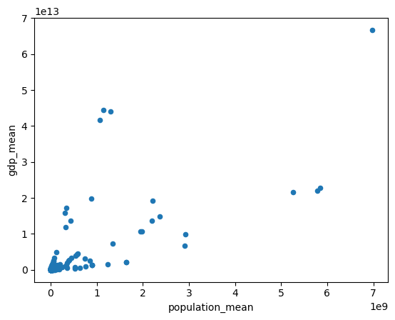

```python
gdp_pop_means.plot.scatter(x='population_mean', y='gdp_mean')
```

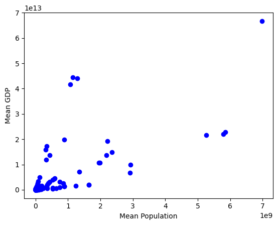

```python
plt.scatter(gdp_pop_means.population_mean,gdp_pop_means.gdp_mean, color='blue')
plt.xlabel("Mean Population")
plt.ylabel("Mean GDP")
plt.show()
```

There appears to be some positive correlation.

Now we move into the correlation heatmap.

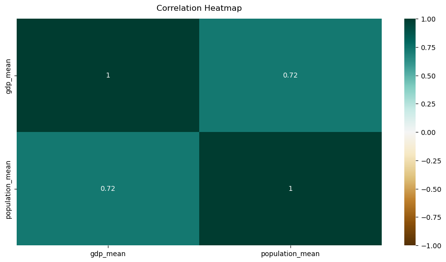

```python
plt.figure(figsize=(12, 6))
heatmap = sns.heatmap(gdp_pop_means.corr(), vmin=-1, vmax=1, annot=True, cmap='BrBG')
heatmap.set_title('Correlation Heatmap', fontdict={'fontsize':12}, pad=12)
```

And now calculate Pearson's correlation coefficient manually

```python
from numpy import cov
from scipy.stats import pearsonr

# calculate covariance matrix
covariance = cov(gdp_pop_means['gdp_mean'], gdp_pop_means['population_mean'])

# calculate Pearson's correlation
corr, _ = pearsonr(gdp_pop_means['gdp_mean'], gdp_pop_means['population_mean'])

print('Covariance: %.3f' % covariance[0][1])
print('Pearsons correlation: %.3f' % corr)
```

```
Covariance: 4450361373368488296448.000
Pearsons correlation: 0.721
```

The correlation coefficient is 0.72 incicating a strong positive correlation between population and GDP, as would be expected.

## Now we check GDP per capita.

Start by adding a column to the datafram for gdp per capita (gdp_mean/population_mean)

```python
gdp_pop_means['gdp_per_capita'] = gdp_pop_means['gdp_mean']/gdp_pop_means['population_mean']
```

```python
gdp_pop_means.head(10)
```

|  | Country Code | gdp_mean | population_mean | gdp_per_capita |
| --- | --- | --- | --- | --- |
| 0 | ABW | 2.553357e+09 | 1.014995e+05 | 25156.352787 |
| 1 | AFE | 7.441522e+11 | 5.321282e+08 | 1398.445250 |
| 2 | AFG | 1.402300e+10 | 3.021299e+07 | 464.138127 |
| 3 | AFW | 5.570494e+11 | 3.594714e+08 | 1549.634656 |
| 4 | AGO | 7.868516e+10 | 2.418655e+07 | 3253.261463 |
| 5 | ALB | 1.092357e+10 | 2.935900e+06 | 3720.686851 |
| 6 | AND | 3.088530e+09 | 7.860035e+04 | 39294.104465 |
| 7 | ARB | 2.037341e+12 | 3.598853e+08 | 5661.085190 |
| 8 | ARE | 2.911172e+11 | 7.403976e+06 | 39319.041310 |
| 9 | ARG | 3.906046e+11 | 4.121000e+07 | 9478.391903 |

Scatter plot mean population against mean gdp per capita

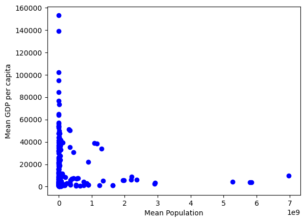

```python
plt.scatter(gdp_pop_means.population_mean,gdp_pop_means.gdp_per_capita, color='blue')
plt.xlabel("Mean Population")
plt.ylabel("Mean GDP per capita")
plt.show()
```

It's much less obvious from this scatterplot if there is any correlation.

Next is the heatmap once again.

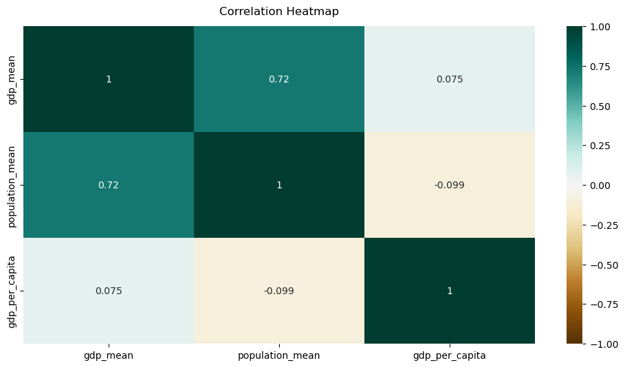

```python
plt.figure(figsize=(12, 6))
heatmap = sns.heatmap(gdp_pop_means.corr(), vmin=-1, vmax=1, annot=True, cmap='BrBG')
heatmap.set_title('Correlation Heatmap', fontdict={'fontsize':12}, pad=12)
```

And now calculate Pearson's correlation coefficient manually

```python
from numpy import cov
from scipy.stats import pearsonr

# calculate covariance matrix
covariance = cov(gdp_pop_means['gdp_per_capita'], gdp_pop_means['population_mean'])

# calculate Pearson's correlation
corr, _ = pearsonr(gdp_pop_means['gdp_per_capita'], gdp_pop_means['population_mean'])

print('Covariance: %.3f' % covariance[0][1])
print('Pearsons correlation: %.3f' % corr)
```

```
Covariance: -1852681912169.224
Pearsons correlation: -0.099
```

The correlation coefficient between population mean and gdp per capita is -0.099, showing a very slight negative correlation, but it's tiny and probably not significant.

## Task B: Regression

## Train-test data preparation

```python
msk=np.random.rand(len(gdp_pop_means))<0.8
train=gdp_pop_means[msk]
test=gdp_pop_means[~msk]
```

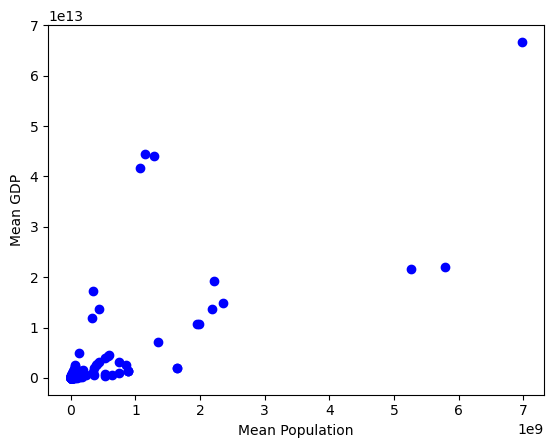

```python
# Train data distribution
plt.scatter(train.population_mean,train.gdp_mean, color='blue')
plt.xlabel("Mean Population")
plt.ylabel("Mean GDP")
plt.show()
```

## Using sklearn package for data modelling

```python
from sklearn import linear_model
regr=linear_model.LinearRegression()
train_x=np.asanyarray(train[['population_mean']])
train_y=np.asanyarray(train[['gdp_mean']])

regr.fit(train_x, train_y)
# The coefficients
print('Coefficients:', regr.coef_)
print('Intercept:', regr.intercept_)
```

```
Coefficients: [[6885.54297571]]
Intercept: [3.4383262e+11]
```

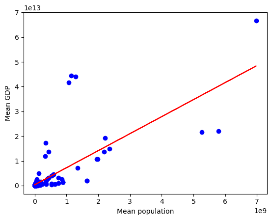

```python
# Plot outputs
plt.scatter(train.population_mean,train.gdp_mean,color='blue')
plt.plot(train_x,regr.coef_[0][0]*train_x + regr.intercept_[0],'-r')
plt.xlabel("Mean population")
plt.ylabel("Mean GDP")
```

## Model evaluation

```python
from sklearn.metrics import r2_score
test_x=np.asanyarray(test[['population_mean']])
test_y=np.asanyarray(test[['gdp_mean']])
test_y_ = regr.predict(test_y)
```

```python
print("Mean absolute error: %.2f" % np.mean(np.absolute(test_y_-test_y)))
print("Residual sum of squares (MSE): %.2f" % np.mean((test_y_-test_y)**2))
print("R2-score: %.2f" % r2_score(test_y_,test_y))
```

```
Mean absolute error: 16449979612316764.00
Residual sum of squares (MSE): 1744212290487224230646678089105408.00
R2-score: -0.18
```

```python
print("R2-score: %.2f" % r2_score(train_x,train_y))
```

```
R2-score: -92457468.14
```

```python
pred_y = regr.predict(test_x)
```

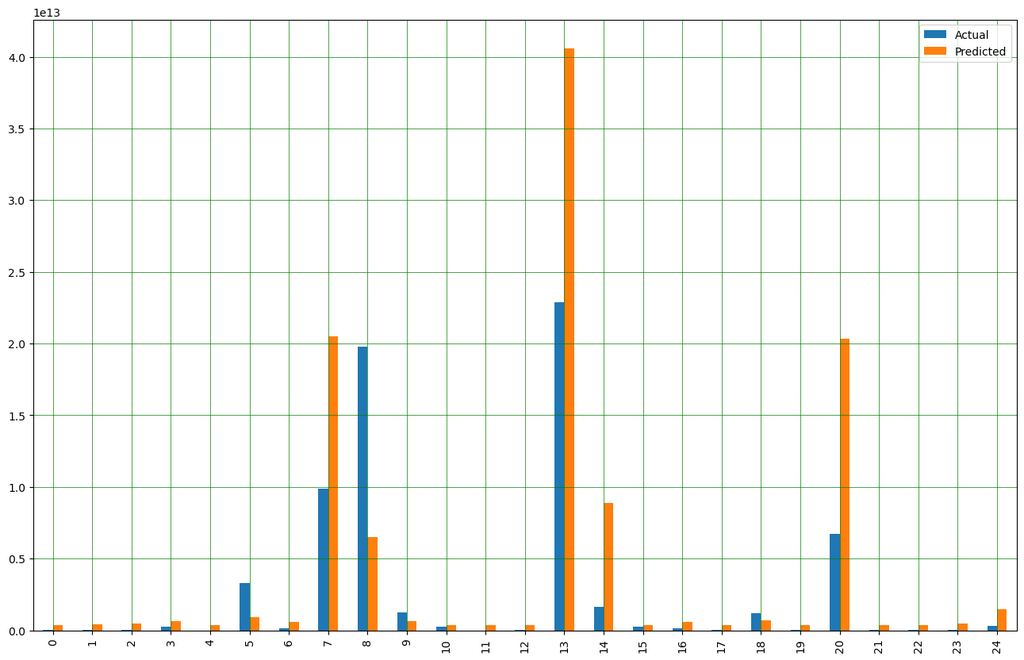

```python
df = pd.DataFrame({'Actual': test_y.flatten(), 'Predicted': pred_y.flatten()})
df1 = df.head(25)
df1.plot(kind='bar',figsize=(16,10))
plt.grid(which='major', linestyle='-', linewidth='0.5', color='green')
plt.grid(which='minor', linestyle=':', linewidth='0.5', color='black')
plt.show()
```

## Now repeat once again for GDP per capita

## Train-test data preparation

```python
msk=np.random.rand(len(gdp_pop_means))<0.8
train=gdp_pop_means[msk]
test=gdp_pop_means[~msk]
```

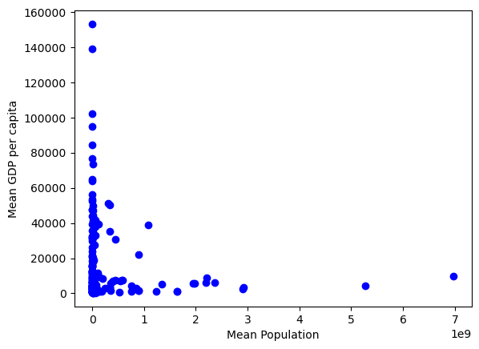

```python
# Train data distribution
plt.scatter(train.population_mean,train.gdp_per_capita, color='blue')
plt.xlabel("Mean Population")
plt.ylabel("Mean GDP per capita")
plt.show()
```

## Using sklearn package for data modelling

```python
from sklearn import linear_model
regr=linear_model.LinearRegression()
train_x=np.asanyarray(train[['population_mean']])
train_y=np.asanyarray(train[['gdp_per_capita']])

regr.fit(train_x, train_y)
# The coefficients
print('Coefficients:', regr.coef_)
print('Intercept:', regr.intercept_)
```

```
Coefficients: [[-3.03113369e-06]]
Intercept: [15502.63927379]
```

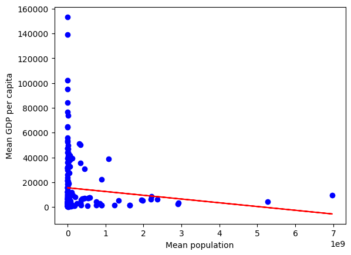

```python
# Plot outputs
plt.scatter(train.population_mean,train.gdp_per_capita,color='blue')
plt.plot(train_x,regr.coef_[0][0]*train_x + regr.intercept_[0],'-r')
plt.xlabel("Mean population")
plt.ylabel("Mean GDP per capita")
```

## Model evaluation

```python
from sklearn.metrics import r2_score
test_x=np.asanyarray(test[['population_mean']])
test_y=np.asanyarray(test[['gdp_per_capita']])
test_y_ = regr.predict(test_y)
```

```python
print("Mean absolute error: %.2f" % np.mean(np.absolute(test_y_-test_y)))
print("Residual sum of squares (MSE): %.2f" % np.mean((test_y_-test_y)**2))
print("R2-score: %.2f" % r2_score(test_y_,test_y))
```

```
Mean absolute error: 13898.53
Residual sum of squares (MSE): 272650024.69
R2-score: -109074913521.91
```

Now test model prediction against the test data

```python
pred_y = regr.predict(test_x)
```

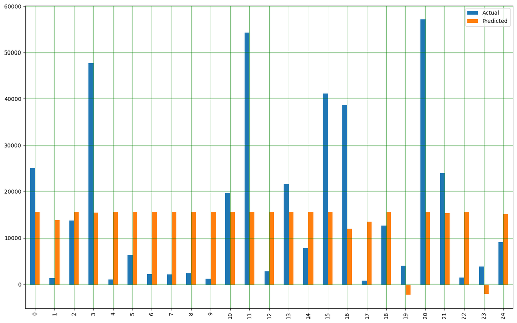

```python
df = pd.DataFrame({'Actual': test_y.flatten(), 'Predicted': pred_y.flatten()})
df1 = df.head(25)
df1.plot(kind='bar',figsize=(16,10))
plt.grid(which='major', linestyle='-', linewidth='0.5', color='green')
plt.grid(which='minor', linestyle=':', linewidth='0.5', color='black')
plt.show()
```